# 04-world-series-home-field

## Probability and Inference — Deliverable 04

## Setup

In the last deliverable I looked at a teams probability of winning a series given the probability of winning a single game and length of series. In the real world the probability of winning a single game is dependent on many outside factors. A big factor, especially in baseball, is home field advantage. Here I will analyse how much of a role home field advantage has in baseball in determining a series outcome. I will only look at 7 game series between two baseball teams.

In a 7 game baseball series the possible schedules are shown in the table below.

| Overall Advantage | Game 1 | Game 2 | Game 3 | Game 4 | Game 5 | Game 6 | Game 7 |
| --- | --- | --- | --- | --- | --- | --- | --- |
| $Team A$ | $Stadium A$ | $Stadium A$ | $Stadium B$ | $Stadium B$ | $Stadium B$ | $Stadium A$ | $Stadium A$ |
| $Team B$ | $Stadium B$ | $Stadium B$ | $Stadium A$ | $Stadium A$ | $Stadium A$ | $Stadium B$ | $Stadium B$ |

Next lets say that playing at home gives a team a 10% (P(winning single head to head game) * 1.1) bump in winning percentage.

## Questions

### Q1

1. Compute analytically the probability that the Team A win the world series when the sequence of game locations is {Away, Away, Home, Home, Home, Away, Away}. Calculate the probability with and without home field advantage when P1 = 0.55. What is the difference in probabilities?

```r
# Calculating probability of world series outcome with team a win probability of 0.55 and a home field advantage of 10% for playing (aahhhaa) and (hhaaahh)
calc_analytical_prob(all_possibilities, 0.55, 1.1, away_field_indicator)
```

```
##    overall_outcome       V1
## 1:               W 0.604221
## 2:               L 0.395779
```

```r
calc_analytical_prob(all_possibilities, 0.55, 1.1, home_field_indicator)
```

```
##    overall_outcome        V1
## 1:               W 0.6345261
## 2:               L 0.3654739
```

```r
# Calculating probability of world series outcome with team a win probability of 0.55 and no home field advantage for playing (aahhhaa) and (hhaaahh)
calc_analytical_prob(all_possibilities, 0.55, 1, away_field_indicator)
```

```
##    overall_outcome        V1
## 1:               W 0.6082878
## 2:               L 0.3917122
```

```r
calc_analytical_prob(all_possibilities, 0.55, 1, home_field_indicator)
```

```
##    overall_outcome        V1
## 1:               W 0.6082878
## 2:               L 0.3917122
```

#### for (aahhhaa) series

We can see that with homefield advantage in play Team A would win the world series with a probability of around 0.6042 given they win 0.55 normally with a 1.1 boost at home and a 1.1 boost for team B at their home and a series schedule of {Away, Away, Home, Home, Home, Away, Away}. We can also see that with the same schedule and relative team strength, team A would win the world series with a probability of 0.6083 if there is no home field advantage (home field advantage = 1.0).

#### for (hhaaahh) series

Here team A would have a higher win probability because they have the opprotunity of playing 4 games at home. There world series win probability is 0.6345. Note: The probability with no home field advantage is the same as for the (aahhhaa) series. This makes sence!

```r
# difference winning with homefield advantage and no homefield advantage (aahhhaa)
calc_analytical_prob(all_possibilities, 0.55, 1.1, away_field_indicator)[[2]][1] - calc_analytical_prob(all_possibilities, 0.55, 1.0, away_field_indicator)[[2]][1]
```

```
## [1] -0.004066825
```

```r
# difference winning with homefield advantage and no homefield advantage (hhaaahh)
calc_analytical_prob(all_possibilities, 0.55, 1.1, home_field_indicator)[[2]][1] - calc_analytical_prob(all_possibilities, 0.55, 1.0, home_field_indicator)[[2]][1]
```

```
## [1] 0.02623829
```

#### for (aahhhaa) series

The team is actaully worse overall if homefield advantage is taken into account, even though they have a higher individual game win percentage. This is because the offset from the advantage the other team gets from having potencially 4 games at home is greater than the baseline advantage team A has. #### for (hhaaahh) series The difference between winning the world series with homefield advantage with a team that wins 0.55 and has the scedule of {Home, Home, Away, Away, Away, Home, Home} and one without homefield advantage is 0.0262. Homefield advantage helps their odds when they have the opprotunity to play at home for 4 games.

### Q2

2. Calculate the same probabilities as the previous question by simulation.

```r
### for (aahhhaa) series
# Simulating 100000 events of starting at home with a winning percentage of 0.55 and a homefield advantage of 10%
set.seed(544)
calc_sim_output(100000, away_field_indicator, 0.55, 1.1)
```

```
## [1] 0.60563
```

```r
# Simulating 100000 events of starting at home with a winning percentage of 0.55 and absolutly no home field advantage
set.seed(544)
calc_sim_output(100000, away_field_indicator, 0.55, 1.0)
```

```
## [1] 0.60901
```

```r
### for (hhaaahh) series
# Simulating 100000 events of starting at home with a winning percentage of 0.55 and a homefield advantage of 10%
set.seed(544)
calc_sim_output(100000, home_field_indicator, 0.55, 1.1)
```

```
## [1] 0.63478
```

```r
# Simulating 100000 events of starting at home with a winning percentage of 0.55 and absolutly no home field advantage
set.seed(544)
calc_sim_output(100000, home_field_indicator, 0.55, 1.0)
```

```
## [1] 0.60901
```

### Q3

3. What is the absolute and relative error for your simulation in the previous question?

```r
### for (aahhhaa) series
# absolute error of simulated home advantage result
set.seed(544)
abs_err_wh_a <- abs(calc_sim_output(100000,away_field_indicator, 0.55, 1.1)- calc_analytical_prob(all_possibilities, 0.55, 1.1,away_field_indicator)[[2]][1])
abs_err_wh_a
```

```
## [1] 0.001409028
```

```r
# absolute error of simulated no home advantage result
set.seed(544)
abs_err_woh_a <- abs(calc_sim_output(100000,away_field_indicator, 0.55, 1.0)- calc_analytical_prob(all_possibilities, 0.55, 1.0,away_field_indicator)[[2]][1])
abs_err_woh_a
```

```
## [1] 0.0007222031
```

```r
### for (hhaaahh) series
# absolute error of simulated home advantage result
set.seed(544)
abs_err_wh <- abs(calc_sim_output(100000,home_field_indicator, 0.55, 1.1)- calc_analytical_prob(all_possibilities, 0.55, 1.1,home_field_indicator)[[2]][1])
abs_err_wh
```

```
## [1] 0.0002539152
```

```r
# absolute error of simulated no home advantage result
set.seed(544)
abs_err_woh <- abs(calc_sim_output(100000,home_field_indicator, 0.55, 1.0)- calc_analytical_prob(all_possibilities, 0.55, 1.0, home_field_indicator)[[2]][1])
abs_err_woh
```

```
## [1] 0.0007222031
```

The absolute errors of all the simulation values are less than 0.0015.

```r
### for (aahhhaa) series
# relative error of simulated home advantage result
set.seed(544)
rel_err_wh_a <-
  abs_err_wh_a / (calc_analytical_prob(all_possibilities, 0.55, 1.1, away_field_indicator)[[2]][1])
rel_err_wh_a
```

```
## [1] 0.002331975
```

```r
# realtive error of simulated no home advantage result
set.seed(544)
rel_err_woh_a <-
  abs_err_woh_a / (calc_analytical_prob(all_possibilities, 0.55, 1.0, away_field_indicator)[[2]][1])
rel_err_woh_a
```

```
## [1] 0.001187272
```

```r
### for (hhaaahh) series
# relative error of simulated home advantage result
set.seed(544)
rel_err_wh <-
  abs_err_wh / (calc_analytical_prob(all_possibilities, 0.55, 1.1, home_field_indicator)[[2]][1])
rel_err_wh
```

```
## [1] 0.0004001652
```

```r
# realtive error of simulated no home advantage result
set.seed(544)
rel_err_woh <-
  abs_err_woh / (calc_analytical_prob(all_possibilities, 0.55, 1.0, home_field_indicator)[[2]][1])
rel_err_woh
```

```
## [1] 0.001187272
```

The relative errors of all the simulation results are under 0.0024.

### Q Bonus

Bonus: Does the difference in probabilites (with vs without home field advantage) depend on the probability that P team 1 wins any individual game?

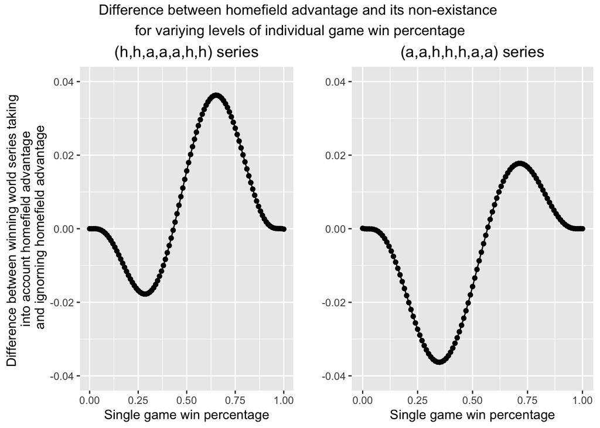

```r
grid.arrange(plot1,plot2,ncol=2, top = "Difference between homefield advantage and its non-existance \nfor variying levels of individual game win percentage")
```

The difference in probabilities of winning world series (with and without homefield advantage) is in fact dependent on the probability of winning a single game.

There is a difference for if you are starting at home or away though! Interestingly enough, if you start at home, your team does not have to be better than the other team for home advantage to start being better than not. This is because if your team plays first in the series (h, h, a, a, a, h, h) you could potencially have one more home game than the opponent at max games. If your team wins 0.44 of individual games, homefield advantage in a series where it helps home team by 10% is better than there being no homefield advantage. Also interesting is that the difference peaks at around 0.65 individual winning probability in the (hhaaahh) series.

In the (a,a,h,h,h,a,a) series the exact opposite is true. Your team needs to be around 0.55 better than the opposing team to offset their advantage from having an extra game at home!

### Q Bonus

Bonus: Does the difference in probabilites (with vs without home field advantage) depend on the advantage factor? (The advantage factor in PH and PA is the 1.1 multiplier that results in a 10% increase for the home team.)

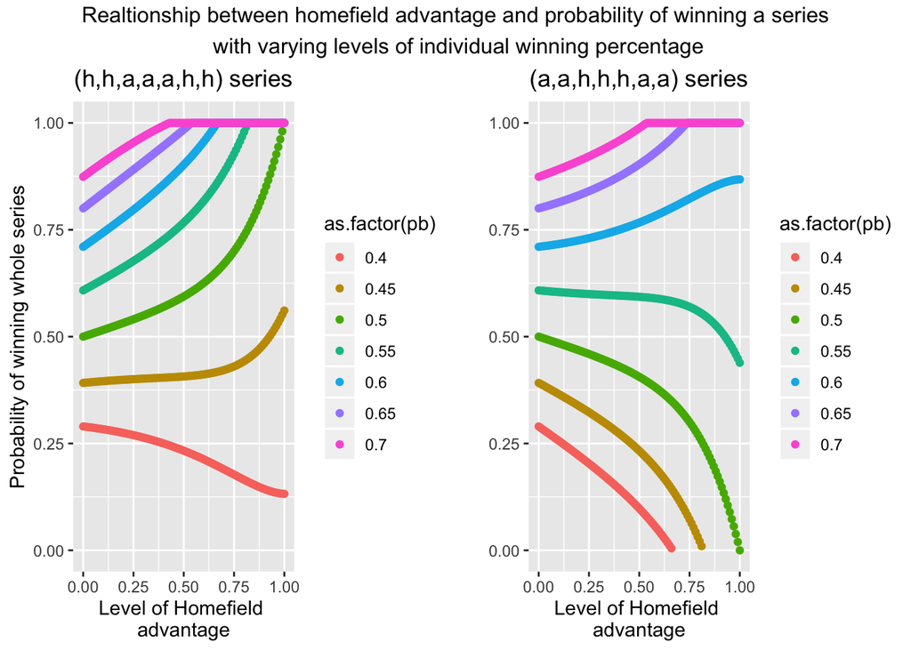

```r
grid.arrange(plot3,plot4,ncol=2, top = "Realtionship between homefield advantage and probability of winning a series\n with varying levels of individual winning percentage")
```